# L06 Layers

Data Visualization (STAT 302)

## Overview

The goal of this lab is to explore more plots in `ggplot2`. Specifically we will be focusing on error bars for uncertainty and practice using multiple layers.

## Datasets

We’ll be using the `cows.rda`, `cdc.txt`, and `tech_stocks.rda` datasets which are already in the `/data` subdirectory in our **data_vis_labs** project. We will also be using the `mpg` dataset which comes packaged with `ggplot2` — use `?ggplot2::mpg` to access its codebook.

```r
# Load package(s)
library(tidyverse)

# Load datasets
load("data/cows.rda")

load("data/tech_stocks.rda")

# Read in the cdc dataset
cdc <- read_delim(file = "data/cdc.txt", delim = "|") %>%
  mutate(genhlth = factor(genhlth,
    levels = c("excellent", "very good", "good", "fair", "poor")
  ))

# Set seed
set.seed(9876)
```

## Exercises

Complete the following exercises.

### Exercise 1

Using `mpg` and the `class_dat` dataset created below, recreate the following graphic as precisely as possible.

*Hints:*

- Transparency is 0.6
- Horizontal position adjustment is 0.1
- Larger points are 5

```r
# Additional dataset for plot
class_dat <- mpg %>%
  group_by(class) %>%
  summarise(
    n = n(),
    hwy = mean(hwy),
    label = str_c("n = ", n, sep = "")
  )
```

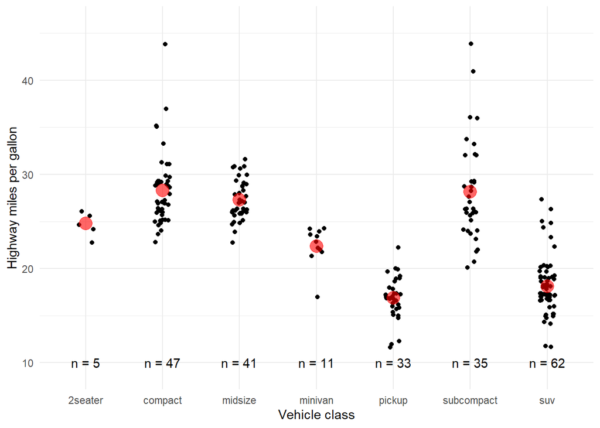

```r
ggplot(mpg, aes(class, hwy)) +
  geom_jitter(width = 0.1) +
  geom_point(aes(class, hwy), data = class_dat, color = "red", alpha = 0.6, size = 5) +
  annotate("text", x=class_dat$class, y=10, label=class_dat$label) +
  ylim(9, 46) +
  labs(x = "Vehicle class", y = "Highway miles per gallon") +
  theme_minimal()
```

### Exercise 2

Using `cow_means` dataset derived from the `cows` dataset, recreate the following graphic as precisely as possible.

*Hints:*

- Hex color code `#56B4E9`
- 95% confidence intervals (1.96 or `qnorm(0.975)`)
- Some useful values: 0.1, 0.7

```r
# Graphic dataset
cow_means <- cows %>%
  filter(breed != "Canadian") %>%
  group_by(breed) %>%
  summarize(
    mean = mean(butterfat),
    se = sd(butterfat) / sqrt(n())
  ) %>%
  mutate(breed = fct_reorder(factor(breed), desc(mean)))
```

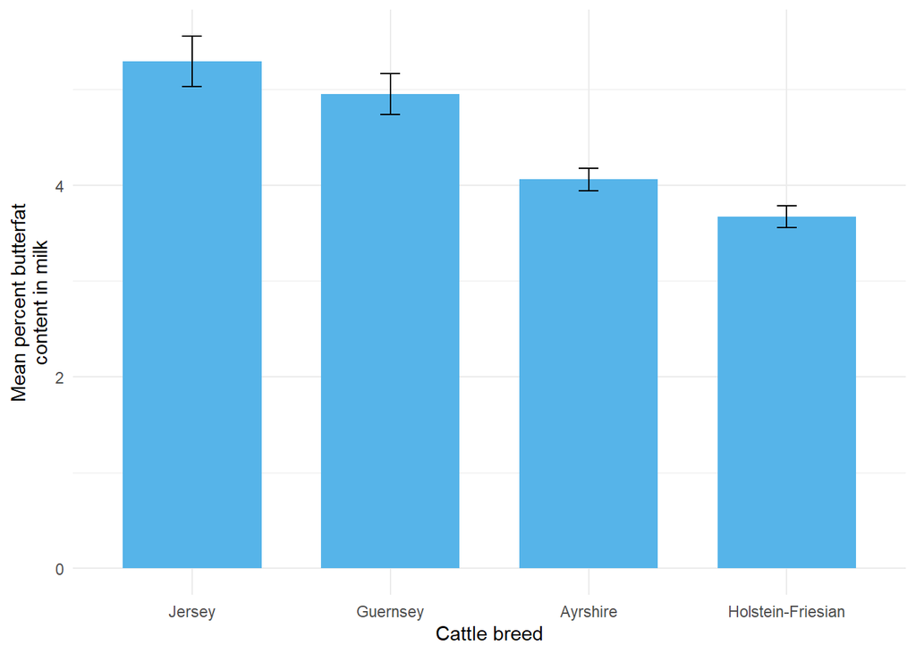

```r
ggplot(cow_means, aes(breed, mean)) +
  geom_bar(stat = "identity", fill = "#56B4E9", width=0.7) +
  geom_errorbar(aes(ymin = mean - qnorm(0.975) * se, ymax = mean + qnorm(0.975) * se), data=cow_means, width=0.1) +
  labs(x = "Cattle breed", y = "Mean percent butterfat\ncontent in milk") +
  theme_minimal()
```

### Exercise 3

Using `perc_increase` dataset derived from the `tech_stocks` dataset, recreate the following graphic as precisely as possible.

*Hints:*

- Hex color code `#56B4E9`
- Justification of 1.1
- Size is 5

```r
# percentage increase data
perc_increase <- tech_stocks %>%
  ungroup(ticker) %>%
  arrange(desc(date)) %>%
  distinct(company, .keep_all = TRUE) %>%
  mutate(
    perc = 100 * (price - index_price) / index_price,
    label = str_c(round(perc), "%", sep = ""),
    company = fct_reorder(factor(company), perc)
  )
```

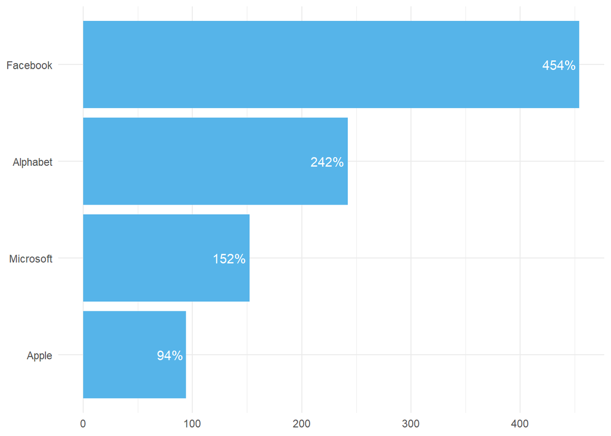

```r
ggplot(perc_increase, aes(perc, company)) +
  geom_bar(stat = "identity", fill = "#56B4E9") +
  annotate("text", x = perc_increase$perc, y = perc_increase$company, label = perc_increase$label, hjust=1.1, color="white") +
  labs(x = NULL, y = NULL) +
  theme_minimal()
```

### Exercise 4

Using `cdc_weight_95ci` dataset derived from the `cdc` dataset, recreate the following graphic as precisely as possible.

*Hints:*

- Useful values: 0.1, 0.5

```r
# 95% CI for weight for genhlth, gender groups
cdc_weight_95ci <- cdc %>%
  group_by(genhlth, gender) %>%
  summarise(
    mean_wt = mean(weight),
    se = sd(weight) / sqrt(n()),
    moe = qt(0.975, n() - 1) * se
  )
```

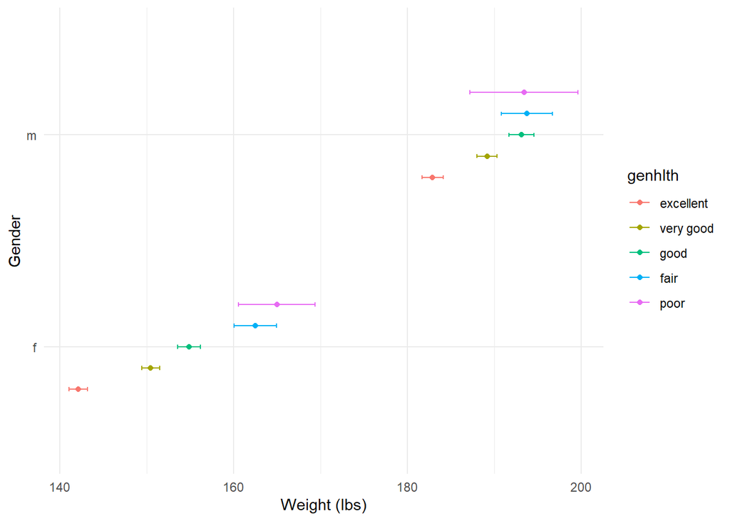

```r
ggplot(cdc_weight_95ci, aes(x = mean_wt, y = gender, group = genhlth, color = genhlth)) +
  geom_point(position = position_dodge(width = 0.5)) +
  geom_errorbar(aes(xmin = mean_wt - moe, xmax = mean_wt + moe, y = gender, x = mean_wt, group = genhlth, color = genhlth), position = position_dodge(width = 0.5), width = 0.1) +
labs(x = "Weight (lbs)", y = "Gender") +
  theme_minimal()
```